# R visualisations in PowerBI

WMC hackathon group 5

19/11/2021

[figure not shown]

# What this document will show you

This document will show you how to set up an R custom visual in PowerBI and will tell you the prerequisites for this to be done.A summary of the requirements and limitations of creating R visuals in PowerBI can be found [here](https://docs.microsoft.com/en-us/power-bi/connect-data/service-r-packages-support), for easy access. Other resources are noted through the document and compiled in Appendix 1.

Please feel free to edit this with any trouble shooting notes with resolutions to common issues.

# Prerequisites:

- You need to be or have the help of the admin of your PC to be able to complete steps 1-5, the inital set up.
- PowerBI currently runs on Microsoft R version 3.4.4. This can be downloaded [here](https://mran.microsoft.com/release-history) and a list of packages in use within this version can be found [here](https://cran.microsoft.com/snapshot/2018-04-01/web/packages/available_packages_by_name.html)

# Initial set up to allow creation of a PowerBI R visual

Steps 1-5 all require *administrator permissions* so be sure to raise a ticket with your local IT as soon as you know you will need to use PowerBI in combination with R.

Information for this section of the document was taken from: https://radacad.com/interactive-map-using-r-and-power-bi-create-custom-visual-part-1

## Step 1

- Install node.js (which essentially is javascript server) from [here](https://nodejs.org/).

## Step 2

- Launch command prompt or power shell

## Step 3

- Navigate to your desired working directory (create a new folder where you want to store the custom visuals if needed)

e.g. `cd C:\Users\be234789\Documents\RCustomvis`

## Step 4

- Install the powerbi-visuals-tools package with Powershell

run: `npm install -g powerbi-visuals-tools`

## Step 5

- Create an rhtml template

# Set up each time you create a PowerBI R visual

## Step 6

- Navigate to the folder where template is stored

e.g. `cd C:\Users\be234789\Documents\RCustomVis\sampleRHTMLVisual`

## Step 7

This is an important step for compilation

- open the pbviz.json file in the sampleRHTMLVisual folder
- edit to add author, description, and support URL & gitHub URL (can be fake urls) to the pbviz.json and then save:

```
        "description":"Horizontal timeline visual build using ggplot and plotly in R",

        "supportUrl":"https://medium.com/@fredtasker/interactive-power-bi-custom-visuals-with-r-a6a4ac998710",

        "gitHubUrl":"https://github.com/fredwise/PM_timeline"},

        ...

        "author":{"name":"Fred Tasker","email":"xxxx.com"}

        ...`
```

## Step 8

- Go back to command prompt/power shell and run the following to compile (make sure working directory sill set to where R script file located)

e.g. `cd C:\Users\be234789\Documents\RCustomVis\sampleRHTMLVisual`

## Step 9

- Run: `pbiviz package`

## Test this has worked

Once successfully compiled the custom PBI visual will now be ready, you can now import the Microsoft Power BI Custom visual file into PBIto test *file found in folder called “dist” in sampleRHTMLVisual folder, will be a .pbiviz file*  
to import a custom visual into PBI go to the additional options in the visualizations pane (…) and select ‘import a visual from a file’.

# Customising your visual

Now that you have the example template you can customise accordingly: * alter the script.R file (will need to retain some elements: the first line`"source('./r_files/flatten_HTML.r')"`, `libraryRequireInstall()` and `internalSaveWidget()` arguments) * add any cran package dependencies from the script to dependencies.json * edit the name of the visual, as well as the icon in pbiviz.json * to change the PBI parameters that feed into the visual - edit the capabilities.json file accordingly (add/remove additional data roles)

Notes on how to do this can be found [here](https://radacad.com/interactive-charts-using-r-and-power-bi-create-custom-visual-part-2)

# Tips for creating R visuals in PowerBI

- Microsoft keep a log of the [Microsoft R (MRAN) release history](https://mran.microsoft.com/release-history), this allows install of past MRAN versions. This makes it easier to test visuals.
- You can still use the most recent version of Microsoft R or R for some things, and MRAN 3.4.4 for visualisations that will go into PowerBI by changing the global options within RStudio

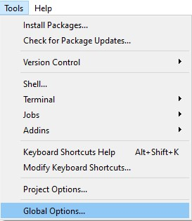

Global options can be found in the Tools tab

[figure not shown]

You can change the R version you are using

[figure not shown]

Pick any of your downloaded R versions to use in the session

# More information

https://radacad.com/create-custom-visual-with-r-and-json-part3

https://radacad.com/create-custom-visual-with-r-and-json-part-4

# Appendix 1 - resources mentioned and used in this document

- Microsoft essential information on creating visuals made using R packages in PowerBI:

https://docs.microsoft.com/en-us/power-bi/connect-data/service-r-packages-support

- Microsoft R (MRAN) release history, allows install of past MRAN versions. This makes it easier to test visuals, as you can download this version and use it to test visuals by swapping R version in use in your global options (mentioned in the tips section):

https://mran.microsoft.com/release-history

- Microsoft has a ‘time machine’ which allows you to examine the different MRAN releases and look at the information at the time of release:

https://mran.microsoft.com/timemachine

https://cran.microsoft.com/snapshot/2018-04-01/web/packages/available_packages_by_name.html

- Where the process we have outlined comes from - a blog by Leila Etaati:

https://radacad.com/interactive-map-using-r-and-power-bi-create-custom-visual-part-1

- Reference in the blog this was made from, detailing pbiviz PowerBI Visual Tools:

https://www.npmjs.com/package/powerbi-visuals-tools

- Required install is from here:

https://nodejs.org/

- Information on customising visuals can be found in these follow-up blogs by Leila Etaati

https://radacad.com/interactive-charts-using-r-and-power-bi-create-custom-visual-part-2

https://radacad.com/create-custom-visual-with-r-and-json-part3

https://radacad.com/create-custom-visual-with-r-and-json-part-4